# Sporulation curve on agar surface

# Replication outliers

I have made 3 technical replicate measurements in the flow-cytometer for each sample. There are some measurements which are obviously way off, e.g. in “WED12” samples some wells did not get SYBR to to pipetting error. To get rid of these I will choose from each triplicate the 2 points that are in best agreement and remove the 3rd point. There is a function to idenify such a point in pacakge ‘outliers’ > outlier {outliers} Finds value with largest difference between it and sample mean, which can be an outlier.

> logical: if set to TRUE, gives vector of logical values, and possible outlier position is marked by TRUE

I will apply the outlier filtering on the number of spores (spore/mL)

[output not shown]

Add T0 to all treatments (measured pre treatment)

```r
d3 <- d3 %>%
  select(bio.rep, trt) %>%
  distinct() %>%
  filter(trt != "preTrt") %>%
  left_join(., d3 %>% filter(time.hr == 0) %>% select(-trt)) %>%
  bind_rows(., d3 %>% filter(trt != "preTrt"))
```

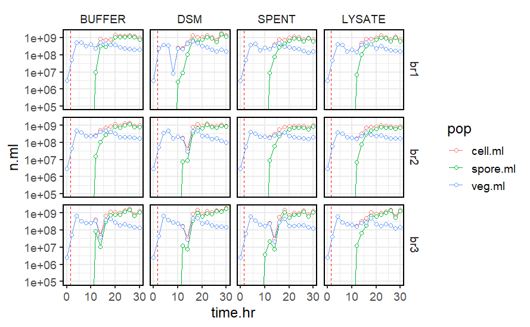

```r
d3 %>%
  group_by(sample.date,exp.plate,t.exp,time.hr, trt, bio.rep) %>%
  summarise(veg.ml = mean(veg.ml), spore.ml = mean(spore.ml)) %>%
  ungroup() %>%
   mutate(cell.ml = veg.ml + spore.ml) %>%

  pivot_longer(cols = c(cell.ml, spore.ml, veg.ml),names_to = "pop", values_to = "n.ml") %>%

  group_by(time.hr, trt, bio.rep, pop) %>%
  summarise(n.ml = mean(n.ml)) %>%
  # mutate(trt = fct_relevel(trt, "LYSATE",after = 3)) %>%

  ggplot(aes(time.hr, n.ml, color = pop)) +
  geom_vline(xintercept = 1.5, color = "red", linetype = 2)+
  geom_line()+
  geom_point(shape = 21, fill = "white")+
  facet_grid( trt %>% fct_relevel("LYSATE",after = 3) ~bio.rep )+
  facet_grid(bio.rep ~ trt %>% fct_relevel("LYSATE",after = 3))+
    theme_bw(base_size = 14)+
  panel_border(color = "black")+
  theme(strip.background = element_blank())+
  coord_cartesian(ylim = c(1e5,NA))+
  scale_y_log10()
```

### export data

```r
d3 %>%
  group_by(sample.date,exp.plate,t.exp,time.hr, trt, bio.rep) %>%
  summarise(veg.ml = mean(veg.ml), spore.ml = mean(spore.ml)) %>%
  ungroup() %>%
   mutate(cell.ml = veg.ml + spore.ml) %>%
  write_csv(here("data", "clean_counts.csv"))
```

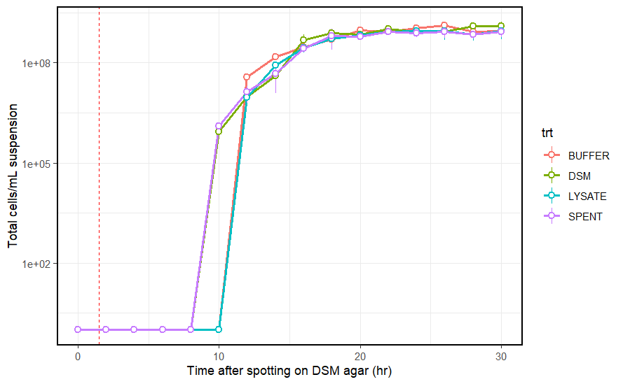

```r
d3 %>%
  group_by(sample.date,exp.plate,t.exp,time.hr, trt, bio.rep) %>%
  summarise(veg.ml = mean(veg.ml), spore.ml = mean(spore.ml)) %>%
  ungroup() %>%
   mutate(cell.ml = veg.ml + spore.ml) %>%

  pivot_longer(cols = c(cell.ml, spore.ml, veg.ml),names_to = "pop", values_to = "n.ml") %>%

  group_by(time.hr, trt, pop) %>%
  summarise(m = mean(n.ml), v = sd(n.ml)) %>%
  filter(pop == "spore.ml") %>%

  ggplot(aes(time.hr, m, color = trt)) +
  geom_vline(xintercept = 1.5, color = "red", linetype = 2)+
  geom_line(size = 1)+
  geom_pointrange(aes(ymax = m+v, ymin = m-v),
                  shape = 21, fill = "white")+
    theme_bw()+
  panel_border(color = "black")+
  theme(strip.background = element_blank())+
  coord_cartesian(ylim = c(1e0,NA))+
  scale_y_log10()+
  ylab("Total cells/mL suspension")+
  xlab("Time after spotting on DSM agar (hr)")
```

```r
NA
```

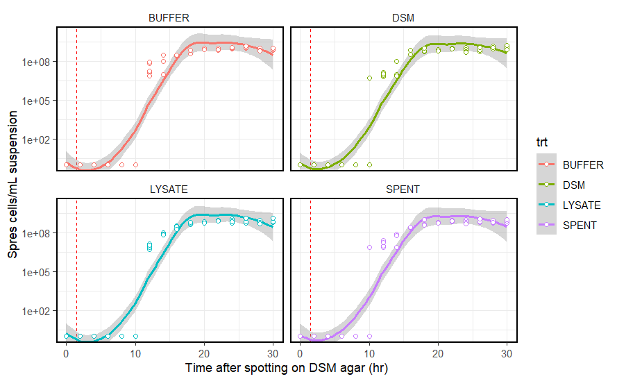

```r
d3 %>%
  group_by(sample.date,exp.plate,t.exp,time.hr, trt, bio.rep) %>%
  summarise(veg.ml = mean(veg.ml), spore.ml = mean(spore.ml)) %>%
  ungroup() %>%
   mutate(cell.ml = veg.ml + spore.ml) %>%

  pivot_longer(cols = c(cell.ml, spore.ml, veg.ml),names_to = "pop", values_to = "n.ml") %>%
  filter(pop == "spore.ml") %>%

  ggplot(aes(time.hr, n.ml, color = trt)) +
  geom_vline(xintercept = 1.5, color = "red", linetype = 2)+
  geom_smooth(size = 1)+
  geom_point(shape = 21, fill = "white")+
    theme_bw()+
  panel_border(color = "black")+
  theme(strip.background = element_blank())+
  coord_cartesian(ylim = c(1e0,NA))+
  scale_y_log10()+
  ylab("Spres cells/mL suspension")+
  xlab("Time after spotting on DSM agar (hr)")+
  facet_wrap(~trt)
```

```r
NA
```

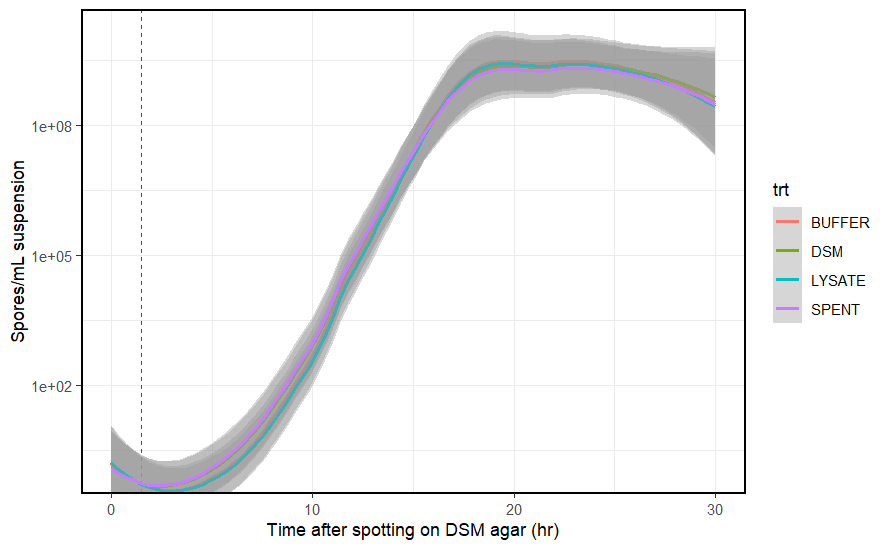

```r
d3 %>%
  group_by(sample.date,exp.plate,t.exp,time.hr, trt, bio.rep) %>%
  summarise(veg.ml = mean(veg.ml), spore.ml = mean(spore.ml)) %>%
  ungroup() %>%
   mutate(cell.ml = veg.ml + spore.ml) %>%

  pivot_longer(cols = c(cell.ml, spore.ml, veg.ml),names_to = "pop", values_to = "n.ml") %>%
  filter(pop == "spore.ml") %>%

  ggplot(aes(time.hr, n.ml, color = trt)) +
  geom_vline(xintercept = 1.5, color = "red", linetype = 2)+
  geom_smooth(size = 1)+
  # geom_point(shape = 21, fill = "white")+
    theme_bw()+
  panel_border(color = "black")+
  theme(strip.background = element_blank())+
  coord_cartesian(ylim = c(1e0,NA))+
  scale_y_log10()+
  ylab("Spores/mL suspension")+
  xlab("Time after spotting on DSM agar (hr)")
```

```r
  # facet_wrap(~trt)
```

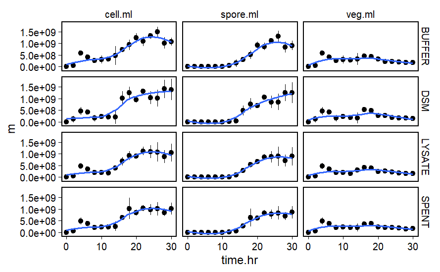

```r
d3 %>%
  group_by(sample.date,exp.plate,t.exp,time.hr, trt, bio.rep) %>%
  summarise(veg.ml = mean(veg.ml), spore.ml = mean(spore.ml)) %>%
  ungroup() %>%
   mutate(cell.ml = veg.ml + spore.ml) %>%

  pivot_longer(cols = c(cell.ml, spore.ml, veg.ml),names_to = "pop", values_to = "n.ml") %>%

    group_by(time.hr, trt,pop) %>%
  summarise(m = mean(n.ml), v= sd(n.ml) ) %>%


  ggplot(aes(time.hr, m))+
  geom_pointrange(aes(ymin = m-v, ymax = m+v))+
  stat_smooth(se = F)+
  # scale_y_log10()+

  theme_cowplot()+
  panel_border(color = "black")+
  facet_grid(trt~pop)+
  theme(strip.background = element_blank())
```

```r
NA
NA
NA
```

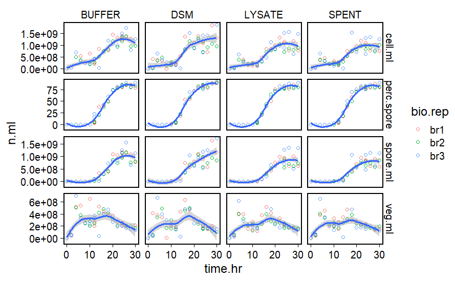

```r
d3 %>%
  group_by(sample.date,exp.plate,t.exp,time.hr, trt,bio.rep) %>%
  summarise(veg.ml = mean(veg.ml) %>% round(), spore.ml = mean(spore.ml)%>% round()) %>%
  ungroup() %>%
   mutate(cell.ml = veg.ml + spore.ml,
          perc.spore =spore.ml*100/cell.ml ) %>%

  # write_csv(here("data","Sporulation_by_Time_FCM.csv"))

  pivot_longer(cols = c(cell.ml, spore.ml, veg.ml, perc.spore),
               names_to = "pop", values_to = "n.ml") %>%

  # mutate(n.ml = if_else(pop == "perc.spore", n.ml, log10(n.ml))) %>%
  group_by(trt,pop) %>%
    ggplot(aes(time.hr, n.ml))+
  geom_point(aes(color = bio.rep), shape = 21)+
  stat_smooth()+
  facet_grid(pop ~ trt, scales = "free_y")+
  theme_cowplot()+
  panel_border(color = "black")+
   theme(strip.background = element_blank())
```

```r
NA
```

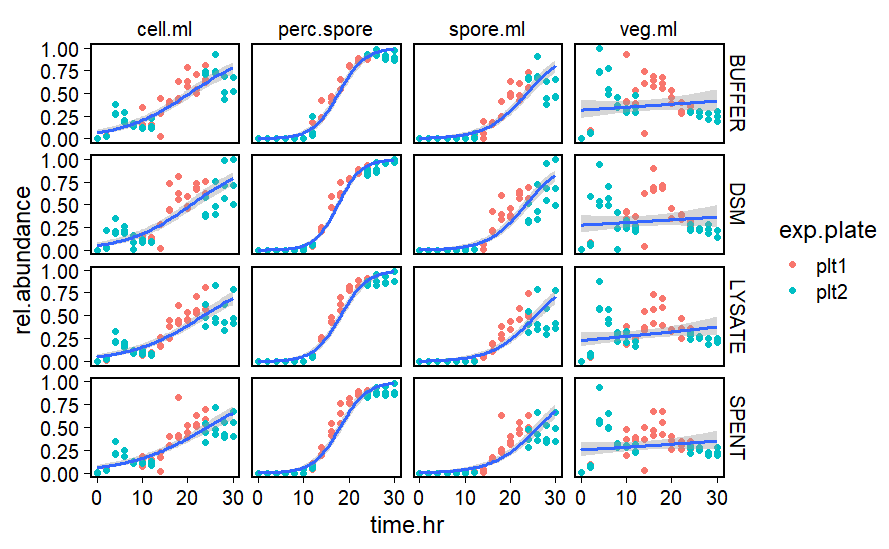

```r
d3 %>%
  group_by(sample.date,exp.plate,t.exp,time.hr, trt,bio.rep) %>%
  summarise(veg.ml = mean(veg.ml), spore.ml = mean(spore.ml)) %>%
  ungroup() %>%
   mutate(cell.ml = veg.ml + spore.ml,
          perc.spore =spore.ml*100/cell.ml ) %>%

  pivot_longer(cols = c(cell.ml, spore.ml, veg.ml, perc.spore),
               names_to = "pop", values_to = "n.ml") %>%
  group_by(pop) %>%
  mutate(rel.abundance = n.ml/max(n.ml)) %>%
    ggplot(aes(time.hr, rel.abundance))+
  geom_point(aes(color = exp.plate))+
  # stat_smooth()+
    stat_smooth(formula = "y ~ x", method = "glm",
              method.args = list(family="quasibinomial"), se = T) +
  facet_grid(trt~pop, scales = "free_y")+

  theme_cowplot()+
  panel_border(color = "black")+
   theme(strip.background = element_blank())
```

```r
NA
```

```r
for (i_trt in unique(test.data$trt)){
  for(i_br in unique(test.data$bio.rep)){
    # for (i_pop in unique(test.data$pop)){
    for (i_pop in "spore.ml"){

      tmp <-
        test.data %>%
        filter(trt == i_trt) %>%
        filter(pop == i_pop) %>%
        filter(bio.rep == i_br) %>%
        select(Time = time.hr,exp.plate,bio.rep, logN) %>%
        as.data.frame()
    tryCatch({
      Gomp1 <-  nls(logN ~ Gompertz(Time, y0, ymax, k, lag),
               data = tmp,
               start = list( ymax=7, k=0.5, lag=5),
              control = list(maxiter = 500))

      # extract model parameters
      coefs <- coef(Gomp1)

      d.stats <- tibble(
          trt = i_trt,
          pop = i_pop,
          bio.rep = i_br,
          # y0   = coefs[[1]],
          ymax = coefs[[1]],
          k   = coefs[[1]],
          lag = coefs[[3]]
      ) %>%
        bind_rows(d.stats,.)
    }, error=function(e){cat("ERROR :",conditionMessage(e), "\n")})

    }
  }
}
```

```
ERROR : singular gradient
ERROR : singular gradient
ERROR : singular gradient
ERROR : singular gradient
ERROR : singular gradient
ERROR : singular gradient
ERROR : singular gradient
```

```r
# Follwing https://www.ipb.pt/~vcadavez/websiteVC/tutorial/rcode/2019-04-28-gompertzmodel/

test.data <-
  d3 %>%
  group_by(sample.date,exp.plate,t.exp,time.hr, trt,bio.rep) %>%
  summarise(veg.ml = mean(veg.ml), spore.ml = mean(spore.ml)) %>%
  ungroup() %>%
   mutate(cell.ml = veg.ml + spore.ml,
          perc.spore =spore.ml*100/cell.ml ) %>%

  pivot_longer(cols = c(cell.ml, spore.ml, veg.ml, perc.spore),
               names_to = "pop", values_to = "n.ml") %>%
  filter(trt == "BUFFER") %>%
  filter(pop == "spore.ml") %>%
   filter(bio.rep == "br2") %>%
  mutate(logN = ifelse(n.ml < 1, 1, log10(n.ml))) %>%
  select(Time = time.hr,exp.plate,bio.rep, logN) %>%
  as.data.frame()
    # plot(test.data$Time, test.data$logN)

Gompertz <- function(x, y0, ymax, k, lag){
      result <- y0 + (ymax -y0)*exp(-exp(k*(lag-x)/(ymax-y0) + 1) )
      return(result)
      }


Gomp1 <-  nls(logN ~ Gompertz(Time, y0, ymax, k, lag),
               data = test.data,
               start = list(y0=0.15, ymax=7, k=0.5, lag=5),
              control = list(maxiter = 500))


# ectract model parameters
coefs <- coef(Gomp1)
coefs
```

```
         y0        ymax           k         lag
-0.01858417  8.79341543 13.72006654 10.33843636
```

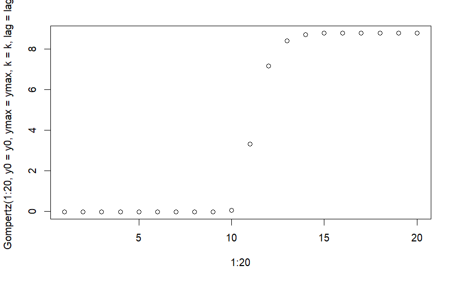

```r
 #       y0      ymax         k       lag
 # 1.569712  8.792401 12.205638 10.578883
y0   <- coefs[[1]]
ymax <- coefs[[2]]
k   <- coefs[[3]]
lag <- coefs[[4]]

plot(1:20,Gompertz(1:20,y0 = y0, ymax = ymax, k = k, lag=lag))
```